# Risk Factor Analysis

## Outcome Variable

**Outcome Variable:** swasted

## Predictor Variables

**Intervention Variable:** meducyrs

**Adjustment Set:**

- arm
- W_mage
- feducyrs
- hhwealth_quart
- W_mhtcm
- W_mwtkg
- W_mbmi
- W_gagebrth
- W_birthwt
- W_birthlen
- single
- W_nrooms
- impsan
- delta_W_mage
- delta_feducyrs
- delta_hhwealth_quart
- delta_W_mhtcm
- delta_W_mwtkg
- delta_W_mbmi
- delta_W_gagebrth
- delta_W_birthwt
- delta_W_birthlen
- delta_single
- delta_W_nrooms
- delta_impsan

## Stratifying Variables

The analysis was stratified on these variable(s):

- agecat
- studyid
- country

## Data Summary

| agecat | studyid | country | meducyrs | swasted | n_cell | n |
| --- | --- | --- | --- | --- | --- | --- |
| Birth | CMC-V-BCS-2002 | INDIA | High | 0 | 49 | 86 |
| Birth | CMC-V-BCS-2002 | INDIA | High | 1 | 0 | 86 |
| Birth | CMC-V-BCS-2002 | INDIA | Low | 0 | 15 | 86 |
| Birth | CMC-V-BCS-2002 | INDIA | Low | 1 | 0 | 86 |
| Birth | CMC-V-BCS-2002 | INDIA | Medium | 0 | 21 | 86 |
| Birth | CMC-V-BCS-2002 | INDIA | Medium | 1 | 1 | 86 |
| Birth | COHORTS | GUATEMALA | High | 0 | 145 | 748 |
| Birth | COHORTS | GUATEMALA | High | 1 | 12 | 748 |
| Birth | COHORTS | GUATEMALA | Low | 0 | 325 | 748 |
| Birth | COHORTS | GUATEMALA | Low | 1 | 19 | 748 |
| Birth | COHORTS | GUATEMALA | Medium | 0 | 220 | 748 |
| Birth | COHORTS | GUATEMALA | Medium | 1 | 27 | 748 |
| Birth | COHORTS | INDIA | High | 0 | 632 | 4879 |
| Birth | COHORTS | INDIA | High | 1 | 24 | 4879 |
| Birth | COHORTS | INDIA | Low | 0 | 1513 | 4879 |
| Birth | COHORTS | INDIA | Low | 1 | 89 | 4879 |
| Birth | COHORTS | INDIA | Medium | 0 | 2494 | 4879 |
| Birth | COHORTS | INDIA | Medium | 1 | 127 | 4879 |
| Birth | COHORTS | PHILIPPINES | High | 0 | 1076 | 2899 |
| Birth | COHORTS | PHILIPPINES | High | 1 | 52 | 2899 |
| Birth | COHORTS | PHILIPPINES | Low | 0 | 810 | 2899 |
| Birth | COHORTS | PHILIPPINES | Low | 1 | 28 | 2899 |
| Birth | COHORTS | PHILIPPINES | Medium | 0 | 892 | 2899 |
| Birth | COHORTS | PHILIPPINES | Medium | 1 | 41 | 2899 |
| Birth | EE | PAKISTAN | High | 0 | 5 | 177 |
| Birth | EE | PAKISTAN | High | 1 | 0 | 177 |
| Birth | EE | PAKISTAN | Low | 0 | 150 | 177 |
| Birth | EE | PAKISTAN | Low | 1 | 6 | 177 |
| Birth | EE | PAKISTAN | Medium | 0 | 16 | 177 |
| Birth | EE | PAKISTAN | Medium | 1 | 0 | 177 |

[output cut: 396 more lines]

The following strata were considered:

- agecat: 24 months, studyid: CMC-V-BCS-2002, country: INDIA
- agecat: 24 months, studyid: COHORTS, country: GUATEMALA
- agecat: 24 months, studyid: COHORTS, country: INDIA
- agecat: 24 months, studyid: COHORTS, country: PHILIPPINES
- agecat: 24 months, studyid: EE, country: PAKISTAN
- agecat: 24 months, studyid: GMS-Nepal, country: NEPAL
- agecat: 24 months, studyid: IRC, country: INDIA
- agecat: 24 months, studyid: JiVitA-3, country: BANGLADESH
- agecat: 24 months, studyid: JiVitA-4, country: BANGLADESH
- agecat: 24 months, studyid: LCNI-5, country: MALAWI
- agecat: 24 months, studyid: MAL-ED, country: BANGLADESH
- agecat: 24 months, studyid: MAL-ED, country: BRAZIL
- agecat: 24 months, studyid: MAL-ED, country: INDIA
- agecat: 24 months, studyid: MAL-ED, country: NEPAL
- agecat: 24 months, studyid: MAL-ED, country: PERU
- agecat: 24 months, studyid: MAL-ED, country: SOUTH AFRICA
- agecat: 24 months, studyid: MAL-ED, country: TANZANIA, UNITED REPUBLIC OF
- agecat: 24 months, studyid: NIH-Birth, country: BANGLADESH
- agecat: 24 months, studyid: NIH-Crypto, country: BANGLADESH
- agecat: 24 months, studyid: PROBIT, country: BELARUS
- agecat: 24 months, studyid: PROVIDE, country: BANGLADESH
- agecat: 24 months, studyid: TanzaniaChild2, country: TANZANIA, UNITED REPUBLIC OF
- agecat: 24 months, studyid: ZVITAMBO, country: ZIMBABWE
- agecat: 6 months, studyid: CMC-V-BCS-2002, country: INDIA
- agecat: 6 months, studyid: COHORTS, country: GUATEMALA
- agecat: 6 months, studyid: COHORTS, country: INDIA
- agecat: 6 months, studyid: COHORTS, country: PHILIPPINES
- agecat: 6 months, studyid: EE, country: PAKISTAN
- agecat: 6 months, studyid: GMS-Nepal, country: NEPAL
- agecat: 6 months, studyid: Guatemala BSC, country: GUATEMALA
- agecat: 6 months, studyid: IRC, country: INDIA
- agecat: 6 months, studyid: JiVitA-3, country: BANGLADESH
- agecat: 6 months, studyid: JiVitA-4, country: BANGLADESH
- agecat: 6 months, studyid: LCNI-5, country: MALAWI
- agecat: 6 months, studyid: MAL-ED, country: BANGLADESH
- agecat: 6 months, studyid: MAL-ED, country: BRAZIL
- agecat: 6 months, studyid: MAL-ED, country: INDIA
- agecat: 6 months, studyid: MAL-ED, country: NEPAL
- agecat: 6 months, studyid: MAL-ED, country: PERU
- agecat: 6 months, studyid: MAL-ED, country: SOUTH AFRICA
- agecat: 6 months, studyid: MAL-ED, country: TANZANIA, UNITED REPUBLIC OF
- agecat: 6 months, studyid: NIH-Birth, country: BANGLADESH
- agecat: 6 months, studyid: NIH-Crypto, country: BANGLADESH
- agecat: 6 months, studyid: PROBIT, country: BELARUS
- agecat: 6 months, studyid: PROVIDE, country: BANGLADESH
- agecat: 6 months, studyid: SAS-CompFeed, country: INDIA
- agecat: 6 months, studyid: SAS-FoodSuppl, country: INDIA
- agecat: 6 months, studyid: TanzaniaChild2, country: TANZANIA, UNITED REPUBLIC OF
- agecat: 6 months, studyid: ZVITAMBO, country: ZIMBABWE
- agecat: Birth, studyid: CMC-V-BCS-2002, country: INDIA
- agecat: Birth, studyid: COHORTS, country: GUATEMALA
- agecat: Birth, studyid: COHORTS, country: INDIA
- agecat: Birth, studyid: COHORTS, country: PHILIPPINES
- agecat: Birth, studyid: EE, country: PAKISTAN
- agecat: Birth, studyid: GMS-Nepal, country: NEPAL
- agecat: Birth, studyid: IRC, country: INDIA
- agecat: Birth, studyid: JiVitA-3, country: BANGLADESH
- agecat: Birth, studyid: JiVitA-4, country: BANGLADESH
- agecat: Birth, studyid: MAL-ED, country: BANGLADESH
- agecat: Birth, studyid: MAL-ED, country: BRAZIL
- agecat: Birth, studyid: MAL-ED, country: INDIA
- agecat: Birth, studyid: MAL-ED, country: NEPAL
- agecat: Birth, studyid: MAL-ED, country: PERU
- agecat: Birth, studyid: MAL-ED, country: SOUTH AFRICA
- agecat: Birth, studyid: MAL-ED, country: TANZANIA, UNITED REPUBLIC OF
- agecat: Birth, studyid: NIH-Birth, country: BANGLADESH
- agecat: Birth, studyid: NIH-Crypto, country: BANGLADESH
- agecat: Birth, studyid: PROBIT, country: BELARUS
- agecat: Birth, studyid: PROVIDE, country: BANGLADESH
- agecat: Birth, studyid: SAS-CompFeed, country: INDIA
- agecat: Birth, studyid: ZVITAMBO, country: ZIMBABWE

### Dropped Strata

Some strata were dropped due to rare outcomes:

- agecat: Birth, studyid: CMC-V-BCS-2002, country: INDIA
- agecat: Birth, studyid: EE, country: PAKISTAN
- agecat: Birth, studyid: MAL-ED, country: BANGLADESH
- agecat: Birth, studyid: MAL-ED, country: BRAZIL
- agecat: Birth, studyid: MAL-ED, country: INDIA
- agecat: Birth, studyid: MAL-ED, country: NEPAL
- agecat: Birth, studyid: MAL-ED, country: PERU
- agecat: Birth, studyid: MAL-ED, country: SOUTH AFRICA
- agecat: Birth, studyid: MAL-ED, country: TANZANIA, UNITED REPUBLIC OF
- agecat: Birth, studyid: PROVIDE, country: BANGLADESH
- agecat: Birth, studyid: SAS-CompFeed, country: INDIA
- agecat: 6 months, studyid: CMC-V-BCS-2002, country: INDIA
- agecat: 6 months, studyid: COHORTS, country: GUATEMALA
- agecat: 6 months, studyid: EE, country: PAKISTAN
- agecat: 6 months, studyid: GMS-Nepal, country: NEPAL
- agecat: 6 months, studyid: Guatemala BSC, country: GUATEMALA
- agecat: 6 months, studyid: JiVitA-4, country: BANGLADESH
- agecat: 6 months, studyid: LCNI-5, country: MALAWI
- agecat: 6 months, studyid: MAL-ED, country: BANGLADESH
- agecat: 6 months, studyid: MAL-ED, country: BRAZIL
- agecat: 6 months, studyid: MAL-ED, country: INDIA
- agecat: 6 months, studyid: MAL-ED, country: NEPAL
- agecat: 6 months, studyid: MAL-ED, country: PERU
- agecat: 6 months, studyid: MAL-ED, country: SOUTH AFRICA
- agecat: 6 months, studyid: MAL-ED, country: TANZANIA, UNITED REPUBLIC OF
- agecat: 6 months, studyid: NIH-Birth, country: BANGLADESH
- agecat: 6 months, studyid: NIH-Crypto, country: BANGLADESH
- agecat: 6 months, studyid: PROBIT, country: BELARUS
- agecat: 6 months, studyid: PROVIDE, country: BANGLADESH
- agecat: 6 months, studyid: SAS-CompFeed, country: INDIA
- agecat: 6 months, studyid: SAS-FoodSuppl, country: INDIA
- agecat: 6 months, studyid: TanzaniaChild2, country: TANZANIA, UNITED REPUBLIC OF
- agecat: 24 months, studyid: CMC-V-BCS-2002, country: INDIA
- agecat: 24 months, studyid: COHORTS, country: GUATEMALA
- agecat: 24 months, studyid: COHORTS, country: INDIA
- agecat: 24 months, studyid: EE, country: PAKISTAN
- agecat: 24 months, studyid: GMS-Nepal, country: NEPAL
- agecat: 24 months, studyid: IRC, country: INDIA
- agecat: 24 months, studyid: LCNI-5, country: MALAWI
- agecat: 24 months, studyid: MAL-ED, country: BANGLADESH
- agecat: 24 months, studyid: MAL-ED, country: BRAZIL
- agecat: 24 months, studyid: MAL-ED, country: INDIA
- agecat: 24 months, studyid: MAL-ED, country: NEPAL
- agecat: 24 months, studyid: MAL-ED, country: PERU
- agecat: 24 months, studyid: MAL-ED, country: SOUTH AFRICA
- agecat: 24 months, studyid: MAL-ED, country: TANZANIA, UNITED REPUBLIC OF
- agecat: 24 months, studyid: NIH-Birth, country: BANGLADESH
- agecat: 24 months, studyid: NIH-Crypto, country: BANGLADESH
- agecat: 24 months, studyid: PROBIT, country: BELARUS
- agecat: 24 months, studyid: PROVIDE, country: BANGLADESH
- agecat: 24 months, studyid: TanzaniaChild2, country: TANZANIA, UNITED REPUBLIC OF

## Methods Detail

We’re interested in the causal parameters $E[Y_a]$ for all values of $a \in \mathcal{A}$. These parameters represent the mean outcome if, possibly contrary to fact, we intervened to set all units to have $A=a$. Under the randomization and positivity assumptions, these are identified by the statistical parameters $\psi_a=E_W[E_{Y|A,W}(Y|A=a,W)]$. In addition, we’re interested in the mean of $Y$, $E[Y]$ under no intervention (the observed mean). We will estimate these parameters by using SuperLearner to fit the relevant likelihood factors – $E_{Y|A,W}(Y|A=a,W)$ and $p(A=a|W)$, and then updating our likelihood fit using a joint TMLE.

For unadjusted analyses ($W=\{\}$), initial likelihoods were estimated using Lrnr_glm to estimate the simple $E(Y|A)$ and Lrnr_mean to estimate $p(A)$. For adjusted analyses, a small library containing Lrnr_glmnet, Lrnr_xgboost, and Lrnr_mean was used.

Having estimated these parameters, we will then use the delta method to estimate relative risks and attributable risks relative to a prespecified baseline level of $A$.

# Results Detail

## Results Plots

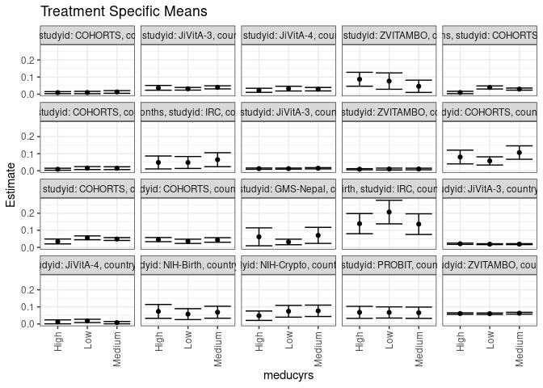

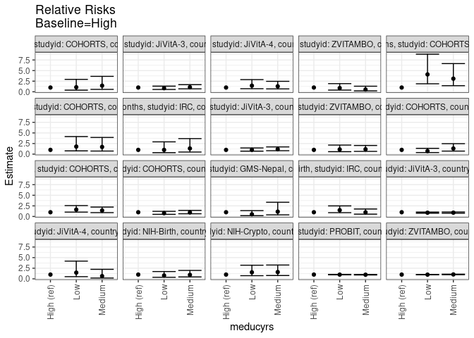

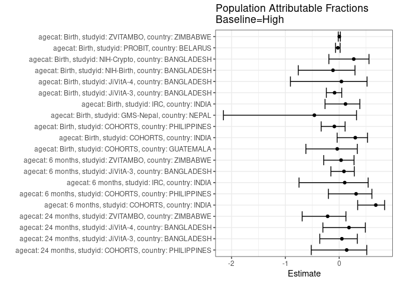

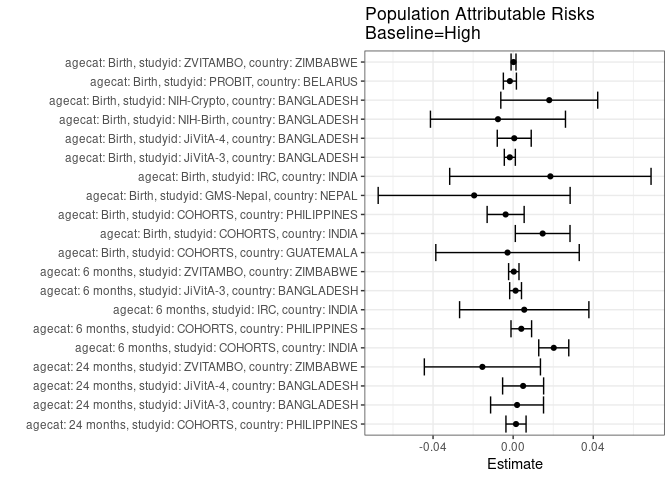

## Results Table

### Parameter: TSM

| agecat | studyid | country | intervention_level | baseline_level | estimate | ci_lower | ci_upper |
| --- | --- | --- | --- | --- | --- | --- | --- |
| Birth | COHORTS | GUATEMALA | High | NA | 0.0803469 | 0.0400980 | 0.1205958 |
| Birth | COHORTS | GUATEMALA | Low | NA | 0.0573483 | 0.0333195 | 0.0813772 |
| Birth | COHORTS | GUATEMALA | Medium | NA | 0.1063218 | 0.0670226 | 0.1456210 |
| Birth | COHORTS | INDIA | High | NA | 0.0344513 | 0.0202050 | 0.0486975 |
| Birth | COHORTS | INDIA | Low | NA | 0.0557990 | 0.0444867 | 0.0671113 |
| Birth | COHORTS | INDIA | Medium | NA | 0.0487949 | 0.0404372 | 0.0571526 |
| Birth | COHORTS | PHILIPPINES | High | NA | 0.0454881 | 0.0333402 | 0.0576360 |
| Birth | COHORTS | PHILIPPINES | Low | NA | 0.0353804 | 0.0228680 | 0.0478928 |
| Birth | COHORTS | PHILIPPINES | Medium | NA | 0.0433778 | 0.0300107 | 0.0567450 |
| Birth | GMS-Nepal | NEPAL | High | NA | 0.0617284 | 0.0092776 | 0.1141792 |
| Birth | GMS-Nepal | NEPAL | Low | NA | 0.0315315 | 0.0152644 | 0.0477987 |
| Birth | GMS-Nepal | NEPAL | Medium | NA | 0.0701754 | 0.0232478 | 0.1171031 |
| Birth | IRC | INDIA | High | NA | 0.1388486 | 0.0798664 | 0.1978307 |
| Birth | IRC | INDIA | Low | NA | 0.2065747 | 0.1375905 | 0.2755589 |
| Birth | IRC | INDIA | Medium | NA | 0.1359301 | 0.0754107 | 0.1964495 |
| Birth | JiVitA-3 | BANGLADESH | High | NA | 0.0210635 | 0.0174119 | 0.0247151 |
| Birth | JiVitA-3 | BANGLADESH | Low | NA | 0.0187209 | 0.0161787 | 0.0212631 |
| Birth | JiVitA-3 | BANGLADESH | Medium | NA | 0.0189007 | 0.0161307 | 0.0216706 |
| Birth | JiVitA-4 | BANGLADESH | High | NA | 0.0124224 | 0.0011008 | 0.0237440 |
| Birth | JiVitA-4 | BANGLADESH | Low | NA | 0.0180941 | 0.0086591 | 0.0275291 |
| Birth | JiVitA-4 | BANGLADESH | Medium | NA | 0.0079260 | 0.0011127 | 0.0147393 |
| Birth | NIH-Birth | BANGLADESH | High | NA | 0.0736723 | 0.0331407 | 0.1142038 |
| Birth | NIH-Birth | BANGLADESH | Low | NA | 0.0576708 | 0.0257787 | 0.0895629 |
| Birth | NIH-Birth | BANGLADESH | Medium | NA | 0.0688849 | 0.0337751 | 0.1039946 |
| Birth | NIH-Crypto | BANGLADESH | High | NA | 0.0484474 | 0.0208120 | 0.0760828 |
| Birth | NIH-Crypto | BANGLADESH | Low | NA | 0.0744162 | 0.0398901 | 0.1089422 |
| Birth | NIH-Crypto | BANGLADESH | Medium | NA | 0.0770327 | 0.0436639 | 0.1104014 |
| Birth | PROBIT | BELARUS | High | NA | 0.0681455 | 0.0329961 | 0.1032950 |
| Birth | PROBIT | BELARUS | Low | NA | 0.0673925 | 0.0346635 | 0.1001214 |
| Birth | PROBIT | BELARUS | Medium | NA | 0.0658831 | 0.0327632 | 0.0990029 |
| Birth | ZVITAMBO | ZIMBABWE | High | NA | 0.0611419 | 0.0568035 | 0.0654804 |
| Birth | ZVITAMBO | ZIMBABWE | Low | NA | 0.0601999 | 0.0558172 | 0.0645826 |
| Birth | ZVITAMBO | ZIMBABWE | Medium | NA | 0.0629696 | 0.0577529 | 0.0681862 |
| 6 months | COHORTS | INDIA | High | NA | 0.0094980 | 0.0024947 | 0.0165012 |
| 6 months | COHORTS | INDIA | Low | NA | 0.0388952 | 0.0298972 | 0.0478931 |
| 6 months | COHORTS | INDIA | Medium | NA | 0.0293508 | 0.0232029 | 0.0354988 |
| 6 months | COHORTS | PHILIPPINES | High | NA | 0.0088670 | 0.0030987 | 0.0146353 |
| 6 months | COHORTS | PHILIPPINES | Low | NA | 0.0157767 | 0.0072669 | 0.0242865 |
| 6 months | COHORTS | PHILIPPINES | Medium | NA | 0.0149942 | 0.0069033 | 0.0230852 |
| 6 months | IRC | INDIA | High | NA | 0.0483871 | 0.0105720 | 0.0862022 |
| 6 months | IRC | INDIA | Low | NA | 0.0482759 | 0.0133443 | 0.0832074 |
| 6 months | IRC | INDIA | Medium | NA | 0.0647482 | 0.0237890 | 0.1057074 |
| 6 months | JiVitA-3 | BANGLADESH | High | NA | 0.0124429 | 0.0089708 | 0.0159151 |
| 6 months | JiVitA-3 | BANGLADESH | Low | NA | 0.0125382 | 0.0095671 | 0.0155092 |
| 6 months | JiVitA-3 | BANGLADESH | Medium | NA | 0.0145307 | 0.0108448 | 0.0182166 |
| 6 months | ZVITAMBO | ZIMBABWE | High | NA | 0.0089786 | 0.0057532 | 0.0122040 |
| 6 months | ZVITAMBO | ZIMBABWE | Low | NA | 0.0099547 | 0.0045310 | 0.0153784 |
| 6 months | ZVITAMBO | ZIMBABWE | Medium | NA | 0.0103123 | 0.0056981 | 0.0149266 |
| 24 months | COHORTS | PHILIPPINES | High | NA | 0.0087816 | 0.0027219 | 0.0148412 |
| 24 months | COHORTS | PHILIPPINES | Low | NA | 0.0093583 | 0.0024568 | 0.0162598 |
| 24 months | COHORTS | PHILIPPINES | Medium | NA | 0.0126582 | 0.0048609 | 0.0204555 |
| 24 months | JiVitA-3 | BANGLADESH | High | NA | 0.0368026 | 0.0229046 | 0.0507006 |
| 24 months | JiVitA-3 | BANGLADESH | Low | NA | 0.0313141 | 0.0234145 | 0.0392137 |
| 24 months | JiVitA-3 | BANGLADESH | Medium | NA | 0.0396437 | 0.0306129 | 0.0486745 |
| 24 months | JiVitA-4 | BANGLADESH | High | NA | 0.0223304 | 0.0103017 | 0.0343590 |
| 24 months | JiVitA-4 | BANGLADESH | Low | NA | 0.0321735 | 0.0183099 | 0.0460372 |
| 24 months | JiVitA-4 | BANGLADESH | Medium | NA | 0.0288522 | 0.0187202 | 0.0389843 |
| 24 months | ZVITAMBO | ZIMBABWE | High | NA | 0.0869565 | 0.0461962 | 0.1277169 |
| 24 months | ZVITAMBO | ZIMBABWE | Low | NA | 0.0762712 | 0.0283242 | 0.1242182 |
| 24 months | ZVITAMBO | ZIMBABWE | Medium | NA | 0.0458015 | 0.0099610 | 0.0816420 |

### Parameter: E(Y)

| agecat | studyid | country | intervention_level | baseline_level | estimate | ci_lower | ci_upper |
| --- | --- | --- | --- | --- | --- | --- | --- |
| Birth | COHORTS | GUATEMALA | NA | NA | 0.0775401 | 0.0583612 | 0.0967191 |
| Birth | COHORTS | INDIA | NA | NA | 0.0491904 | 0.0431214 | 0.0552594 |
| Birth | COHORTS | PHILIPPINES | NA | NA | 0.0417385 | 0.0344572 | 0.0490198 |
| Birth | GMS-Nepal | NEPAL | NA | NA | 0.0422535 | 0.0266438 | 0.0578632 |
| Birth | IRC | INDIA | NA | NA | 0.1574344 | 0.1188345 | 0.1960344 |
| Birth | JiVitA-3 | BANGLADESH | NA | NA | 0.0194018 | 0.0169900 | 0.0218136 |
| Birth | JiVitA-4 | BANGLADESH | NA | NA | 0.0129653 | 0.0075421 | 0.0183885 |
| Birth | NIH-Birth | BANGLADESH | NA | NA | 0.0660870 | 0.0457632 | 0.0864107 |
| Birth | NIH-Crypto | BANGLADESH | NA | NA | 0.0664781 | 0.0481022 | 0.0848539 |
| Birth | PROBIT | BELARUS | NA | NA | 0.0665123 | 0.0333611 | 0.0996634 |
| Birth | ZVITAMBO | ZIMBABWE | NA | NA | 0.0613321 | 0.0571909 | 0.0654732 |
| 6 months | COHORTS | INDIA | NA | NA | 0.0297762 | 0.0252454 | 0.0343071 |
| 6 months | COHORTS | PHILIPPINES | NA | NA | 0.0129342 | 0.0086762 | 0.0171922 |
| 6 months | IRC | INDIA | NA | NA | 0.0539216 | 0.0319786 | 0.0758646 |
| 6 months | JiVitA-3 | BANGLADESH | NA | NA | 0.0136578 | 0.0115849 | 0.0157307 |
| 6 months | ZVITAMBO | ZIMBABWE | NA | NA | 0.0093029 | 0.0072609 | 0.0113448 |
| 24 months | COHORTS | PHILIPPINES | NA | NA | 0.0102082 | 0.0062264 | 0.0141901 |
| 24 months | JiVitA-3 | BANGLADESH | NA | NA | 0.0387570 | 0.0344303 | 0.0430837 |
| 24 months | JiVitA-4 | BANGLADESH | NA | NA | 0.0273074 | 0.0220923 | 0.0325225 |
| 24 months | ZVITAMBO | ZIMBABWE | NA | NA | 0.0715935 | 0.0472820 | 0.0959051 |

### Parameter: RR

| agecat | studyid | country | intervention_level | baseline_level | estimate | ci_lower | ci_upper |
| --- | --- | --- | --- | --- | --- | --- | --- |
| Birth | COHORTS | GUATEMALA | High | High | 1.0000000 | 1.0000000 | 1.000000 |
| Birth | COHORTS | GUATEMALA | Low | High | 0.7137592 | 0.3734593 | 1.364144 |
| Birth | COHORTS | GUATEMALA | Medium | High | 1.3232845 | 0.7114522 | 2.461279 |
| Birth | COHORTS | INDIA | High | High | 1.0000000 | 1.0000000 | 1.000000 |
| Birth | COHORTS | INDIA | Low | High | 1.6196511 | 1.0220245 | 2.566739 |
| Birth | COHORTS | INDIA | Medium | High | 1.4163466 | 0.9054894 | 2.215418 |
| Birth | COHORTS | PHILIPPINES | High | High | 1.0000000 | 1.0000000 | 1.000000 |
| Birth | COHORTS | PHILIPPINES | Low | High | 0.7777948 | 0.4996915 | 1.210676 |
| Birth | COHORTS | PHILIPPINES | Medium | High | 0.9536077 | 0.6349455 | 1.432198 |
| Birth | GMS-Nepal | NEPAL | High | High | 1.0000000 | 1.0000000 | 1.000000 |
| Birth | GMS-Nepal | NEPAL | Low | High | 0.5108108 | 0.1890368 | 1.380301 |
| Birth | GMS-Nepal | NEPAL | Medium | High | 1.1368421 | 0.3855700 | 3.351947 |
| Birth | IRC | INDIA | High | High | 1.0000000 | 1.0000000 | 1.000000 |
| Birth | IRC | INDIA | Low | High | 1.4877699 | 0.8887448 | 2.490546 |
| Birth | IRC | INDIA | Medium | High | 0.9789808 | 0.5445244 | 1.760074 |
| Birth | JiVitA-3 | BANGLADESH | High | High | 1.0000000 | 1.0000000 | 1.000000 |
| Birth | JiVitA-3 | BANGLADESH | Low | High | 0.8887842 | 0.7651741 | 1.032363 |
| Birth | JiVitA-3 | BANGLADESH | Medium | High | 0.8973187 | 0.7633128 | 1.054851 |
| Birth | JiVitA-4 | BANGLADESH | High | High | 1.0000000 | 1.0000000 | 1.000000 |
| Birth | JiVitA-4 | BANGLADESH | Low | High | 1.4565742 | 0.5084765 | 4.172481 |
| Birth | JiVitA-4 | BANGLADESH | Medium | High | 0.6380449 | 0.1818054 | 2.239215 |
| Birth | NIH-Birth | BANGLADESH | High | High | 1.0000000 | 1.0000000 | 1.000000 |
| Birth | NIH-Birth | BANGLADESH | Low | High | 0.7828022 | 0.3585401 | 1.709095 |
| Birth | NIH-Birth | BANGLADESH | Medium | High | 0.9350176 | 0.4414410 | 1.980464 |
| Birth | NIH-Crypto | BANGLADESH | High | High | 1.0000000 | 1.0000000 | 1.000000 |
| Birth | NIH-Crypto | BANGLADESH | Low | High | 1.5360200 | 0.7364306 | 3.203775 |
| Birth | NIH-Crypto | BANGLADESH | Medium | High | 1.5900267 | 0.7775829 | 3.251338 |
| Birth | PROBIT | BELARUS | High | High | 1.0000000 | 1.0000000 | 1.000000 |
| Birth | PROBIT | BELARUS | Low | High | 0.9889489 | 0.9387160 | 1.041870 |
| Birth | PROBIT | BELARUS | Medium | High | 0.9667993 | 0.9106089 | 1.026457 |
| Birth | ZVITAMBO | ZIMBABWE | High | High | 1.0000000 | 1.0000000 | 1.000000 |
| Birth | ZVITAMBO | ZIMBABWE | Low | High | 0.9845926 | 0.9468766 | 1.023811 |
| Birth | ZVITAMBO | ZIMBABWE | Medium | High | 1.0298914 | 0.9713992 | 1.091906 |
| 6 months | COHORTS | INDIA | High | High | 1.0000000 | 1.0000000 | 1.000000 |
| 6 months | COHORTS | INDIA | Low | High | 4.0951039 | 1.8908265 | 8.869072 |
| 6 months | COHORTS | INDIA | Medium | High | 3.0902230 | 1.4358105 | 6.650932 |
| 6 months | COHORTS | PHILIPPINES | High | High | 1.0000000 | 1.0000000 | 1.000000 |
| 6 months | COHORTS | PHILIPPINES | Low | High | 1.7792611 | 0.7642414 | 4.142369 |
| 6 months | COHORTS | PHILIPPINES | Medium | High | 1.6910163 | 0.7262384 | 3.937462 |
| 6 months | IRC | INDIA | High | High | 1.0000000 | 1.0000000 | 1.000000 |
| 6 months | IRC | INDIA | Low | High | 0.9977011 | 0.3439183 | 2.894314 |
| 6 months | IRC | INDIA | Medium | High | 1.3381295 | 0.4895938 | 3.657299 |
| 6 months | JiVitA-3 | BANGLADESH | High | High | 1.0000000 | 1.0000000 | 1.000000 |
| 6 months | JiVitA-3 | BANGLADESH | Low | High | 1.0076518 | 0.6978113 | 1.455067 |
| 6 months | JiVitA-3 | BANGLADESH | Medium | High | 1.1677874 | 0.8028480 | 1.698612 |
| 6 months | ZVITAMBO | ZIMBABWE | High | High | 1.0000000 | 1.0000000 | 1.000000 |
| 6 months | ZVITAMBO | ZIMBABWE | Low | High | 1.1087195 | 0.5773818 | 2.129023 |
| 6 months | ZVITAMBO | ZIMBABWE | Medium | High | 1.1485498 | 0.6470079 | 2.038872 |
| 24 months | COHORTS | PHILIPPINES | High | High | 1.0000000 | 1.0000000 | 1.000000 |
| 24 months | COHORTS | PHILIPPINES | Low | High | 1.0656751 | 0.3881533 | 2.925812 |
| 24 months | COHORTS | PHILIPPINES | Medium | High | 1.4414557 | 0.5715907 | 3.635109 |
| 24 months | JiVitA-3 | BANGLADESH | High | High | 1.0000000 | 1.0000000 | 1.000000 |
| 24 months | JiVitA-3 | BANGLADESH | Low | High | 0.8508659 | 0.5449060 | 1.328620 |
| 24 months | JiVitA-3 | BANGLADESH | Medium | High | 1.0771978 | 0.6895697 | 1.682724 |
| 24 months | JiVitA-4 | BANGLADESH | High | High | 1.0000000 | 1.0000000 | 1.000000 |
| 24 months | JiVitA-4 | BANGLADESH | Low | High | 1.4407976 | 0.7233059 | 2.870014 |
| 24 months | JiVitA-4 | BANGLADESH | Medium | High | 1.2920638 | 0.6774483 | 2.464290 |
| 24 months | ZVITAMBO | ZIMBABWE | High | High | 1.0000000 | 1.0000000 | 1.000000 |
| 24 months | ZVITAMBO | ZIMBABWE | Low | High | 0.8771186 | 0.4004071 | 1.921388 |
| 24 months | ZVITAMBO | ZIMBABWE | Medium | High | 0.5267176 | 0.2115570 | 1.311379 |

### Parameter: PAR

| agecat | studyid | country | intervention_level | baseline_level | estimate | ci_lower | ci_upper |
| --- | --- | --- | --- | --- | --- | --- | --- |
| Birth | COHORTS | GUATEMALA | High | NA | -0.0028068 | -0.0386197 | 0.0330061 |
| Birth | COHORTS | INDIA | High | NA | 0.0147392 | 0.0010823 | 0.0283960 |
| Birth | COHORTS | PHILIPPINES | High | NA | -0.0037496 | -0.0129919 | 0.0054928 |
| Birth | GMS-Nepal | NEPAL | High | NA | -0.0194749 | -0.0674050 | 0.0284552 |
| Birth | IRC | INDIA | High | NA | 0.0185858 | -0.0316940 | 0.0688657 |
| Birth | JiVitA-3 | BANGLADESH | High | NA | -0.0016617 | -0.0044166 | 0.0010933 |
| Birth | JiVitA-4 | BANGLADESH | High | NA | 0.0005429 | -0.0079350 | 0.0090208 |
| Birth | NIH-Birth | BANGLADESH | High | NA | -0.0075853 | -0.0413017 | 0.0261311 |
| Birth | NIH-Crypto | BANGLADESH | High | NA | 0.0180307 | -0.0061670 | 0.0422284 |
| Birth | PROBIT | BELARUS | High | NA | -0.0016333 | -0.0048922 | 0.0016257 |
| Birth | ZVITAMBO | ZIMBABWE | High | NA | 0.0001901 | -0.0010382 | 0.0014184 |
| 6 months | COHORTS | INDIA | High | NA | 0.0202783 | 0.0127813 | 0.0277752 |
| 6 months | COHORTS | PHILIPPINES | High | NA | 0.0040672 | -0.0010750 | 0.0092095 |
| 6 months | IRC | INDIA | High | NA | 0.0055345 | -0.0267498 | 0.0378187 |
| 6 months | JiVitA-3 | BANGLADESH | High | NA | 0.0012148 | -0.0017341 | 0.0041638 |
| 6 months | ZVITAMBO | ZIMBABWE | High | NA | 0.0003243 | -0.0022668 | 0.0029153 |
| 24 months | COHORTS | PHILIPPINES | High | NA | 0.0014267 | -0.0035989 | 0.0064523 |
| 24 months | JiVitA-3 | BANGLADESH | High | NA | 0.0019544 | -0.0112636 | 0.0151724 |
| 24 months | JiVitA-4 | BANGLADESH | High | NA | 0.0049770 | -0.0052617 | 0.0152158 |
| 24 months | ZVITAMBO | ZIMBABWE | High | NA | -0.0153630 | -0.0443536 | 0.0136276 |

### Parameter: PAF

| agecat | studyid | country | intervention_level | baseline_level | estimate | ci_lower | ci_upper |
| --- | --- | --- | --- | --- | --- | --- | --- |
| Birth | COHORTS | GUATEMALA | High | NA | -0.0361978 | -0.6186007 | 0.3366456 |
| Birth | COHORTS | INDIA | High | NA | 0.2996347 | -0.0379718 | 0.5274327 |
| Birth | COHORTS | PHILIPPINES | High | NA | -0.0898348 | -0.3347458 | 0.1101378 |
| Birth | GMS-Nepal | NEPAL | High | NA | -0.4609053 | -2.1514607 | 0.3227761 |
| Birth | IRC | INDIA | High | NA | 0.1180545 | -0.2629001 | 0.3840939 |
| Birth | JiVitA-3 | BANGLADESH | High | NA | -0.0856445 | -0.2378646 | 0.0478572 |
| Birth | JiVitA-4 | BANGLADESH | High | NA | 0.0418754 | -0.9064856 | 0.5184843 |
| Birth | NIH-Birth | BANGLADESH | High | NA | -0.1147777 | -0.7598982 | 0.2938629 |
| Birth | NIH-Crypto | BANGLADESH | High | NA | 0.2712274 | -0.1914281 | 0.5542245 |
| Birth | PROBIT | BELARUS | High | NA | -0.0245559 | -0.0685065 | 0.0175869 |
| Birth | ZVITAMBO | ZIMBABWE | High | NA | 0.0031002 | -0.0171338 | 0.0229317 |
| 6 months | COHORTS | INDIA | High | NA | 0.6810218 | 0.3441589 | 0.8448601 |
| 6 months | COHORTS | PHILIPPINES | High | NA | 0.3144546 | -0.2005200 | 0.6085259 |
| 6 months | IRC | INDIA | High | NA | 0.1026393 | -0.7462155 | 0.5388563 |
| 6 months | JiVitA-3 | BANGLADESH | High | NA | 0.0889487 | -0.1539258 | 0.2807037 |
| 6 months | ZVITAMBO | ZIMBABWE | High | NA | 0.0348592 | -0.2876884 | 0.2766133 |
| 24 months | COHORTS | PHILIPPINES | High | NA | 0.1397585 | -0.5193606 | 0.5129429 |
| 24 months | JiVitA-3 | BANGLADESH | High | NA | 0.0504270 | -0.3599531 | 0.3369707 |
| 24 months | JiVitA-4 | BANGLADESH | High | NA | 0.1822589 | -0.3024819 | 0.4865952 |
| 24 months | ZVITAMBO | ZIMBABWE | High | NA | -0.2145863 | -0.6877207 | 0.1259100 |